# Methods 3, Week 3:

Bayesian Thinking: Experimental and Implementational Aspects

Maxime Sainte-Marie

# A quick look back at set theory

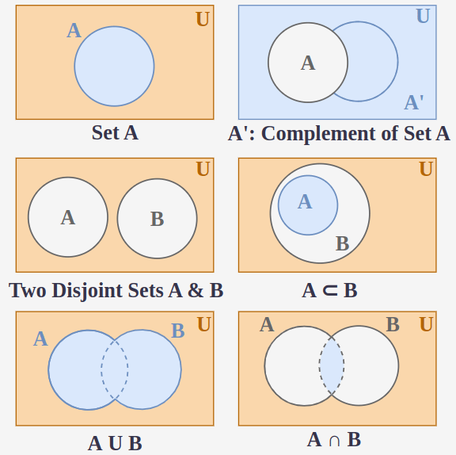

## A quick look back at conditional probability

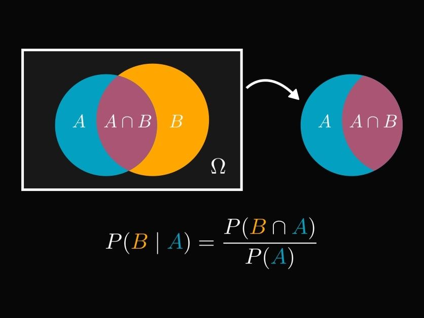

## A quick look back at Bayes’ Theorem

$Pr(A|B) = Pr(A)\frac{Pr(B|A)}{Pr(B)}$

- $Pr(B|A)$ = Conditional probability that needs to be reversed
- $Pr(A)$ = Categorical (marginal) probability of unknown event
- $Pr(B)$ = Categorical (marginal) probability of known event

## $Pr(A)$ = Marginal probability of unknown event (Prior)

- Most analysts assume uninformative priors
  - no strong assumptions about the parameter estimates other than the shape of their distribution
  - the results are strongly determined by the current experiment’s data
  - no strong rationale for bayesian
- Informative priors
  - Bigger effect on the posterior estimation
  - Effect larger if the data is limited or highly variable

## $Pr(B)$ = Marginal probability of known event

- Probability of known event, regardless of whether the unknown event occurs
  - Sum of all possible joint probabilities of known event $B$ with all possible unknown events $A_{i}$ in sample space $S_A$

$Pr(B) = \sum\limits_{A_i \in S_A} Pr(A_i\cap B) = \sum\limits_{A_i \in S_A}Pr(B|A_i)Pr(A_i)$

Bayes’ theorem becomes:

$Pr(A|B) = Pr(A)\frac{Pr(B|A)}{\sum\limits_{A_i \in S_A} Pr(A_i\cap B)} = Pr(A)\frac{Pr(B|A)}{\sum\limits_{A_i \in S_A}Pr(B|A_i)Pr(A_i)}$

# Example: Prostate cancer test

- A 30 year-old man has a positive blood test for a prostate cancer marker (PSA). What is the probability he has prostate cancer ($can$) given one positive test ($pos$)?
  - The test gives positive results to positive cases 90% of the time (TPR = .9)
  - The test gives gives positive results to negative cases 50% of the time (FPR = .5).
  - Prostate cancer incidence rate for 30 year-old men is 0.001%
  - Possible unknown events in the sample space:
    - Cancer ($can$)
    - Not cancer ($\sim can$)

## Estimating prostate cancer probability

**Given**

$$\begin{align}
Pr(\textrm{pos}|\textrm{can}) &= .9\\
Pr(\textrm{pos}|\sim\textrm{can}) &= .5\\
Pr(can) &= .00001
\end{align}$$

**Then**

$$\begin{align}
Pr(can|pos) &= Pr(can)\frac{Pr(pos|can)}{(Pr(pos|can)Pr(can)) +
(Pr(pos|\sim can)Pr(\sim can))}\\
Pr(can|pos) &= .00001 \times \frac{.9}{(.9 \times .00001)+(.5 \times
(1 - .00001))}\\
Pr(can|pos) &= .000018\\
\end{align}$$

## Bayesian Updating of Prostate Cancer Probability

- Second positive test?
  - New Prior = posterior probability for first test ($Pr(A) = .000018$)

**Then**

$$\begin{align}
Pr(can|pos) &= .000018 \times \frac{.9}{(.9 \times .000018)+(.5
\times .999982)}\\
Pr(can|pos) &= .000032
\end{align}$$

**More positive tests?**

## Incremental Science

- We continue to gather data to evaluate a particular scientific hypothesis
  - We do not begin anew each time we attempt to answer a hypothesis, because prior research provides us with a priori information concerning the merit of the hypothesis
  - This approach moves psychology from a bunch of individual studies that are occasionally combined using meta-analysis to one that approaches the best estimate for parameters by having earlier studies inform the current one

# From probability points to probability distributions

- Exact probabilities are rare -> multiple factors at play
  - Prostate cancer: Family history, genetics, obesity, height, pesticides, ethnicity, hormones…
  - Representativity of samples, relative frequencies
  - Population quantities are not known or fixed
- Distributions allow to represent uncertainty regarding the true value of specific parameters
  - Represent prior uncertainty about model parameters with a probability distribution, and update prior uncertainty with evidence to get less uncertain posterior probability distributions for parameters

## Distributional Bayes

$f(\theta|data) = f(\theta)\frac{f(data|\theta)}{f(data)}$

$$\begin{align}
f(\theta|data) =&\;\textrm{posterior distribution of the parameter
}\theta\\
f(data|\theta) =&\;\textrm{sampling density for the data}\\
&\;\textrm{(not a proper density function,}\\
&\;\textrm{but proportional to likelihood function)}\\
f(\theta) =&\;\textrm{Prior distribution for the parameter}\\
f(data) =&\;\textrm{Marginal probability of the data} = \int
f(data|\theta)f(\theta)d\theta\\
&\; (\textrm{aka marginal likelihood, acts as normalizing
constant}\\
&\; \textrm{to make posterior density proper})
\end{align}$$

## Marginal probability/likelihood

$f(data) = \int f(data|\theta)f(\theta)d\theta\\$

- Normalizing constant making posterior density proper
  - Simply scales the posterior density, so often left out

$Posterior \propto Prior \times Likelihood$

- Proportionality
  - If a is proportional to b, then a and b differ only by a multiplicative constant
    - Not a problem for Bayesian analysis
      - Not taking into account the marginal likelihood does not alter the relative frequencies of different values of a random variable

# Implementation of Bayesian inference

- Obtaining the analytical form of posterior distributions is generally intractable
  - No closed form expression for the product of the likelihood function by the prior distribution
    - A closed-form expression is a mathematical expression that can be evaluated in a finite number of expressions
      - Involves some kind of limit/infinity
    - Data distribution cannot be written down on paper
- Posterior distributions most often approximated
  - Exception: Conjugate priors and prior mixtures

## MCMC Posterior Distribution Approximation

- Computer–driven sampling method allowing to characterize a distribution without knowing all of the distribution’s mathematical properties by randomly sampling values out of the distribution.
- Monte-Carlo
  - Practice of estimating the properties of a distribution by examining random samples from the distribution
  - As the number of samples increases, it converges to an accurate representation of the posterior
- Markov Chain = Special sequential process
  - Chain: Each random sample is used as a stepping stone to generate the next random sample (hence the chain)
    - Markovian: each new sample depends only on the one before it

## BRMS (Bayesian Regression Models using Stan)

- Attempt at bridging frequentist and Bayesian practices by taking up and extending lme4’s syntax
- Gateway to STAN (more flexible, covered in Advanced Cognitive Modeling)

# Bayes? Why?… BA*WHY*ES?

[interactive chart not shown]

## Advantages

- Incorporation of prior knowledge
  - Useful when historical data or expert knowledge can provide insights
- Flexibility
  - Can handle many statistical models: complex hierarchical models, non-linear models, models with many parameters
- Uncertainty quantification
  - Measure, shrink, propagate uncertainty in hypotheses and parameters
- Small sample sizes
  - Incorporation of prior information stabilizes estimates when samples are small

## More advantages

- Sequential analysis
  - Bayesian updating allows for incremental inferences based on gradual accumulation of data
- Posterior distribution
  - Provide more information than point estimates
- Handling missing data
  - Treat missing values as parameters to estimate
- Bayesian Machine Learning
  - Model generalization, uncertainty in predictions, model selection and hyperparameter tuning

## Challenges

- Complexity
  - less ritualistic
    - justification-based
    - polymorphic
  - longer
  - fragile
- conducive to awareness and thoroughness
  - Background knowledge, assumptions, implications